# Cocktail ingredients

## Tidylo para el análisis de correspondencia

Soy nuevo usando está librería y es por ello que usare en mayor medida la documentación que ofrece el paquete desde R.

Ahora veamos las relaciones entre las presentaciones de vasos y los ingredientes

```r
ingredientes_vaso<-cocktails%>%
  count(glass,ingredient,sort = TRUE)

ingredientes_vaso%>%
  head(4)
```

```
## # A tibble: 4 x 3
##   glass          ingredient       n
##   <chr>          <chr>        <int>
## 1 Cocktail glass Gin             37
## 2 Collins Glass  Vodka           20
## 3 Cocktail glass Dry Vermouth    19
## 4 Highball glass Vodka           18
```

Ahora a través de `bind_log_odds` buscaré las probabilidades de registros por cada bigram

```r
cocktail_log_odds <- ingredientes_vaso %>%
  bind_log_odds(glass, ingredient, n)
```

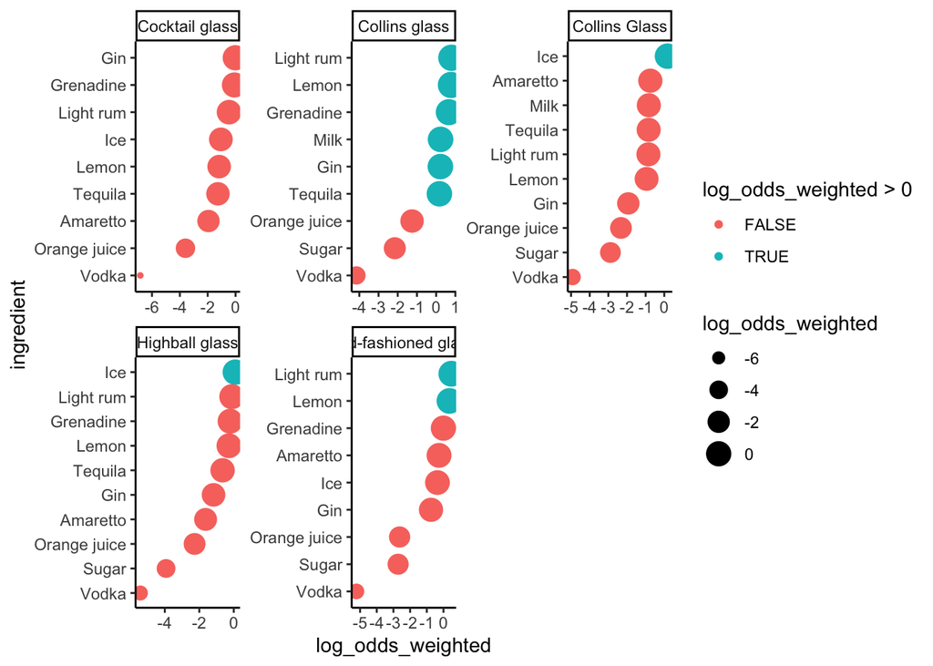

```r
cocktail_log_odds%>%
  mutate(glass=fct_lump(glass,5),
         ingredient=fct_lump(ingredient,10))%>%
  filter(glass!='Other')%>%
  filter(ingredient!='Other')%>%
  arrange(desc(log_odds_weighted))%>%
  mutate(ingredient=reorder_within(ingredient,log_odds_weighted,glass))%>%
  filter(n>1)%>%
  ggplot(aes(log_odds_weighted,ingredient, color=log_odds_weighted>0))+
  geom_point(aes(size=log_odds_weighted))+
  scale_y_reordered()+
  facet_wrap(~glass, scales='free')
```

Estas probabilidades enseñan mucho sobre la correspondencia de los vasos , ingredientes y el cocktel. Pero ahora veamos como es el comportamiento por presentación de cada coctel, esto en término de probabilidades.

```r
top10<-cocktail_log_odds%>%
  group_by(glass)%>%
  summarize(total=n())%>%
  arrange(desc(total))%>%
  top_n(10)
```

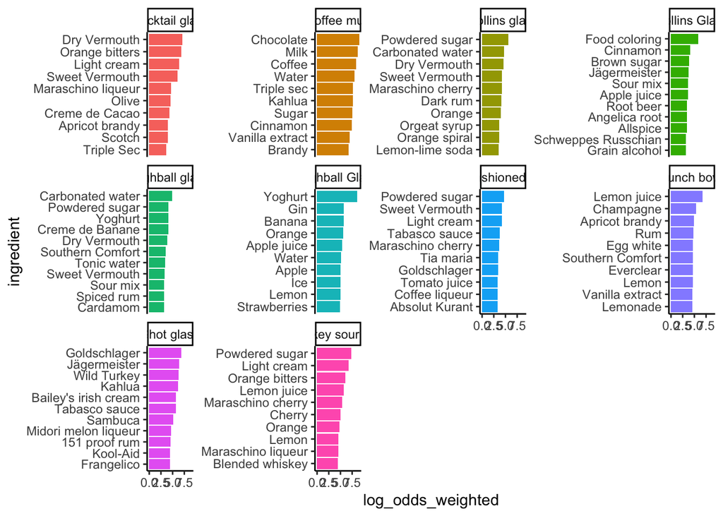

```r
cocktail_log_odds%>%
  filter(glass %in% top10$glass)%>%
  group_by(glass)%>%
  top_n(10)%>%
  ungroup()%>%
  mutate(ingredient=reorder_within(ingredient, log_odds_weighted,glass))%>%
  ggplot(aes(log_odds_weighted, ingredient, fill=glass))+
  geom_col(show.legend = FALSE)+
  facet_wrap(~glass, scales = 'free_y')+
  scale_y_reordered()
```

```r
library(ggrepel)
top3<-cocktail_log_odds%>%
  group_by(glass)%>%
  summarize(total=n())%>%
  arrange(desc(total))%>%
  top_n(3)
```

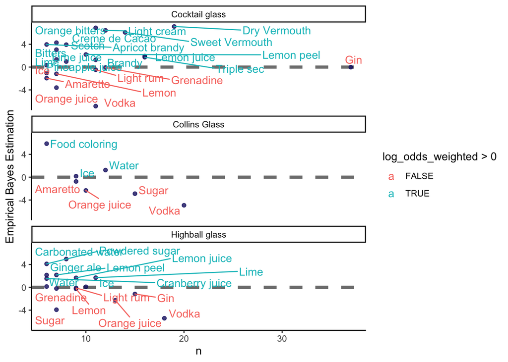

```r
cocktail_log_odds %>%
  filter(glass %in% top3$glass ,
         n > 5) %>%
  ggplot(aes(n, log_odds_weighted, label = ingredient, color=log_odds_weighted>0)) +
  geom_hline(yintercept = 0, color = "gray50", lty = 2, size = 1.5) +
  geom_point(alpha = 0.8, color = "midnightblue") +
  geom_text_repel(force = TRUE)+
  facet_wrap(~glass,ncol = 1)+
  labs(y='Empirical Bayes Estimation')
```

Esta información si es diciente, ahora se puede comprender como es la probabilidad bayesiana sobre lo que debe ir en cada copa y lo que jamás debe estar mezclado en cada una de ellas.

Ahora suponga que desea trabajar con un estimador no informativo, el resultado sería el siguiente

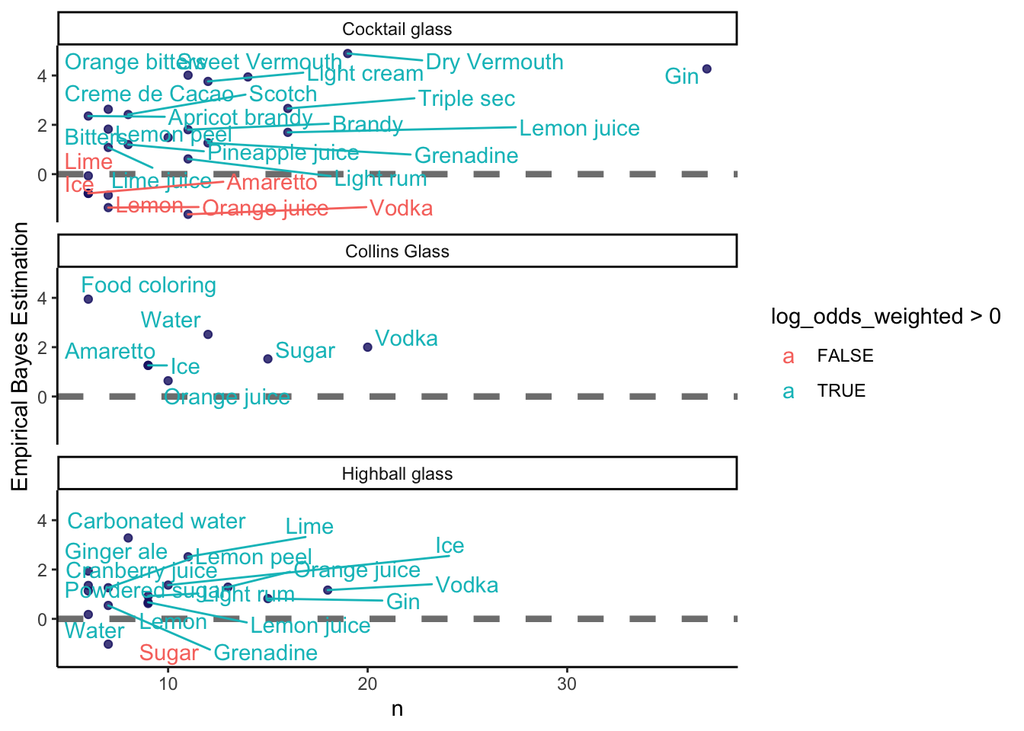

```r
cocktail_log_odds <- ingredientes_vaso %>%
  bind_log_odds(glass, ingredient, n, uninformative = TRUE,unweighted = TRUE)


cocktail_log_odds %>%
  filter(glass %in% top3$glass ,
         n > 5) %>%
  ggplot(aes(n, log_odds_weighted, label = ingredient, color=log_odds_weighted>0)) +
  geom_hline(yintercept = 0, color = "gray50", lty = 2, size = 1.5) +
  geom_point(alpha = 0.8, color = "midnightblue") +
  geom_text_repel(force = TRUE)+
  facet_wrap(~glass,ncol = 1)+
  labs(y='Empirical Bayes Estimation')
```

Las dierencias con los datos no informativos, dan registros regularizados, donde la previa no existe y con base a ello encontramos desde un punto de vista frecuentista (no se porque alguien lo quisiera trabajar así) como es la agrupación de los datos.

Espero que les guste este post!